# Lab 4: Posterior Simulation from Bayes Rules Walkthrough

2022-07-14

```r
library(janitor)
library(tidyverse)
```

In 1996, world chess champion (and human!) Gary Kasparov played a much anticipated six-game chess match against the IBM supercomputer Deep Blue. Of the six games, Kasparov won three, drew two, and lost one.

He was to do a rematch in 1997. Let $\pi$ denoted Kasparov’s chances of winning any particular game in a re-match.

For this example we will only consider 3 possible values of $\pi$, each with a given prior belief. This prior has a is weighted towards the belief that Kasparov got better overtime.

| $\pi$ | 0.2 | 0.5 | 0.8 | Total |
| --- | --- | --- | --- | --- |
| $f(\pi)$ | 0.10 | 0.25 | 0.65 | 1 |

In the end, Kasparov only won one of the six games against Deep Blue in 1997. We want to use this information to update our belief of Kasparov’s chances of winning any particular game in a re-match.

Assuming each match is independent, we can say that the likelihood of $y$ wins out of 6 matched is binomially distributed, given a value of $\pi$.

We want to use our prior and likelihood to simulate data which approximates the posterior, without actually having to calculate it.

Ultimately, we’ll simulate 10,000 scenarios of the six-game chess series. To begin, set up the possible values of win probability $\pi$ and the corresponding prior model $f(\pi)$.

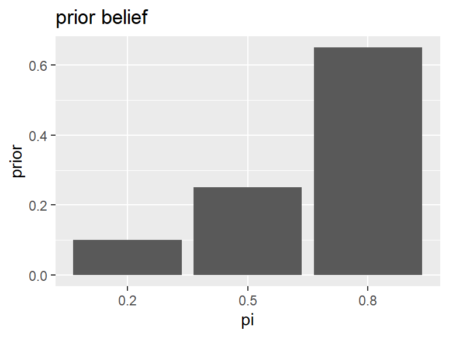

```r
# Define possible win probabilities
chess <- data.frame(pi = c(0.2, 0.5, 0.8))

# Define the prior model
prior <- c(0.10, 0.25, 0.65)

chess %>%
  mutate(pi = factor(pi)) %>%
  mutate(prior = prior) %>%
ggplot(aes(x = pi, y = prior)) +
  geom_col() +
  ggtitle("prior belief")
```

Next, simulate 10,000 possible outcomes of $\pi$ from the prior model and store the results in the `chess_sim` data frame.

```r
# Simulate 10000 values of pi from the prior
set.seed(84735)

chess_sim <- sample_n(
  chess,
  size = 10000,
  weight = prior,
  replace = TRUE
)

# Simulate 10000 match outcomes
chess_sim <- chess_sim %>%
  mutate(y = rbinom(10000, size = 6, prob = pi))

# Check it out
chess_sim %>%
  head(3)
```

```
##    pi y
## 1 0.5 3
## 2 0.5 3
## 3 0.8 4
```

Finally, let’s focus on the simulated outcomes that match the observed data that Kasparov won one game.

```r
# Focus on simulations with y = 1
win_one <- chess_sim %>%
  filter(y == 1)

# Summarize the posterior approximation
win_one %>%
  tabyl(pi) %>%
  adorn_totals("row")
```

```
##     pi   n    percent
##    0.2 404 0.60388640
##    0.5 253 0.37817638
##    0.8  12 0.01793722
##  Total 669 1.00000000
```

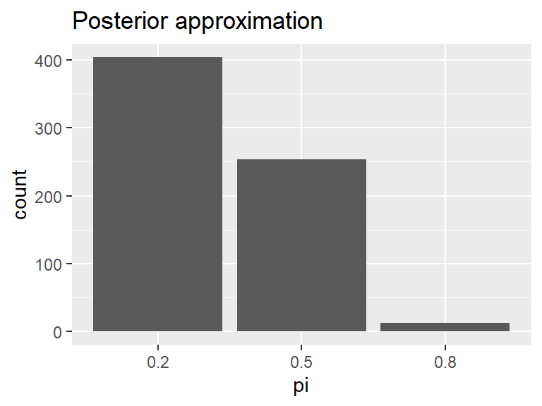

```r
# Plot the posterior approximation
win_one %>%
  mutate(pi = factor(pi)) %>%
ggplot(aes(x = pi)) +
  geom_bar() +
  ggtitle("Posterior approximation")
```